# Manejo y almacenamiento de datos

Autor/a

Verónica Andreo

Fecha de publicación

12 de septiembre de 2023

En este segundo ejercicio de familiarización con GRASS GIS, vamos a explorar la base de datos de GRASS (o lo que usualmente llamaremos *grassdata*), ver cómo crear nuevos proyectos y mapsets, cómo cambiar de mapset y leer datos de mapsets diferentes al actual, realizar reproyecciones, e importar y exportar datos.

## Creación de un nuevo proyecto (location)

Tenemos diferentes opciones para crear proyectos (locations) nuevos en GRASS GIS:

- Desde la GUI
  - botón *Crear nuevo location* en el menú del panel Data Catalog

[figure not shown]

  - desde el menú principal: Settings >> GRASS working environment >> Create new location

[figure not shown]

- Desde la terminal o la pestaña Consola
  - con la opción *`-c`* en el comando de inicio [`grass`](https://grass.osgeo.org/grass-stable/manuals/grass.html) + la ruta al nuevo location y un archivo geo-referenciado o un código EPSG

```bash
# con archivo geo-referenciado
grass -c geofile.tif grassdata/UTM20S

# con código epsg
grass -c EPSG:32720 grassdata/UTM20S
```

**Tarea**

Siguiendo los pasos ejemplificados en la siguiente figura, vamos a crear un nuevo proyecto “latlong” utilizando el código [EPSG](http://epsg.io/) 4326. Notar que una vez completado el proceso, GRASS cambia al nuevo proyecto.

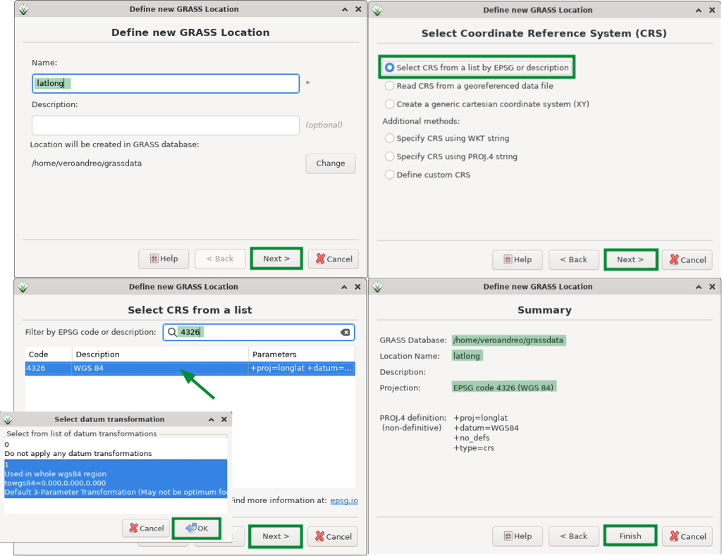

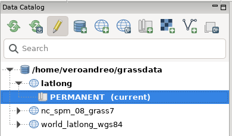

Los pasos de arriba se podrían haber reemplazado por el siguiente comando desde la terminal o la pestaña Consola dentro del panel lateral:

```bash
# Crear un nuevo location con EPSG:4326
grass -c EPSG:4326 $HOME/grassdata/latlong
```

Cuando creamos un nuevo proyecto de esta manera, GRASS abrirá una nueva sesión en el proyecto creado.

## Crear un nuevo mapset

También existen varias opciones para crear mapsets dentro de los proyectos.

- Desde la GUI
  - botón *Crear nuevo mapset* desde el menú del panel Data Catalog

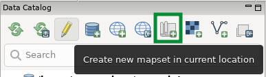

  - desde el menú principal: Settings >> GRASS working environment >> Create new mapset

[figure not shown]

- Desde la terminal o la pestaña Consola
  - con el comando [g.mapset](https://grass.osgeo.org/grass-stable/manuals/g.mapset.html)

```bash
g.mapset mapset=curso
```

GRASS cambia automáticamente al nuevo mapset creado.

**Tarea**

Crear un nuevo mapset llamado *curso* dentro del location *latlong* con el método que deseen.

## Eliminar y renombrar proyectos y mapsets

Simplemente se elimina el directorio desde el explorador de archivos del sistema o se utiliza el menú contextual. Notar que tiene que estar activado el modo edición y que para eliminar proyectos o mapsets, debemos estar en proyectos y mapsets diferentes de aquellos que deseamos eliminar.

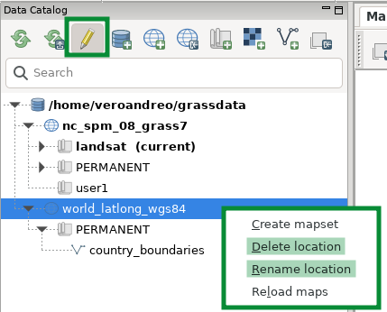

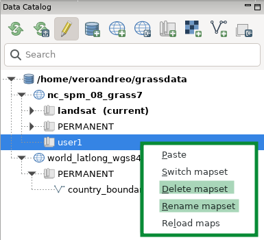

## Cambiar de mapset

- Desde la GUI:

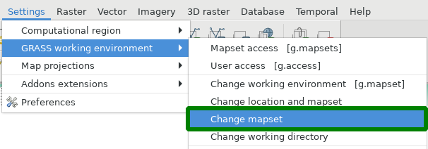

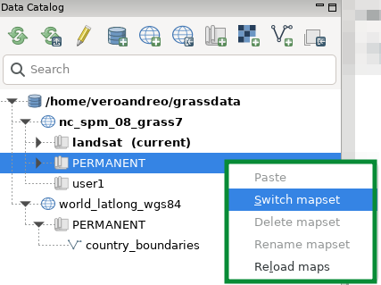

- Desde la terminal o la Consola:

```bash
# imprimir el mapset actual
g.mapset -p

# cambiar al mapset PERMANENT
g.mapset mapset=PERMANENT
```

## Agregar mapsets a la lista de mapsets accesibles

A veces se requiere *leer datos de otro mapset* y usarlos para algún procesamiento. Entonces es necesario **ver** ese mapset desde el mapset actual donde estamos trabajando.

```bash
# imprimir el mapset actual
g.mapset -p
# imprimir los mapsets accesibles
g.mapsets -p
# agregar *user1* a la lista de mapsets accesibles
g.mapsets mapset=user1 operation=add
# corroborar que es visible
g.mapsets -p
```

**Nota**

Estas operaciones se realizan dentro de un mismo proyecto. No es posible agregar/ver mapas de otros proyectos (locations).

## Importar mapas raster y vectoriales

- [r.in.gdal](https://grass.osgeo.org/grass-stable/manuals/r.in.gdal.html): Importa datos raster en GRASS usando la librería GDAL

```bash
r.in.gdal input=myraster.tif output=myraster
```

- [v.in.ogr](https://grass.osgeo.org/grass-stable/manuals/v.in.ogr.html): Importa datos vectoriales en GRASS usando la librería OGR.

```bash
v.in.ogr input=myvector.shp output=myvector
```

**Importante**

Para usar estos comandos, los mapas deben tener **el mismo sistema de coordenadas que el location al que los queremos importar**

**Nota**

Cómo obtener los metadatos de cualquier mapa raster?

```bash
gdalinfo <mapname>
```

Alternativamente, podemos usar [r.import](https://grass.osgeo.org/grass-stable/manuals/r.import.html) y [v.import](https://grass.osgeo.org/grass-stable/manuals/v.import.html) que ofrecen *re-proyección al vuelo* y también, remuestreo y recorte para los datos raster. En este caso, entonces, los mapas raster y vectoriales no necesitan tener el mismo sistema de coordenadas que el proyecto (location) de destino. Veamos dos ejemplos y sigamos las instrucciones que nos muestran.

#### Importar un mapa raster en el proyecto NC

[figure not shown]

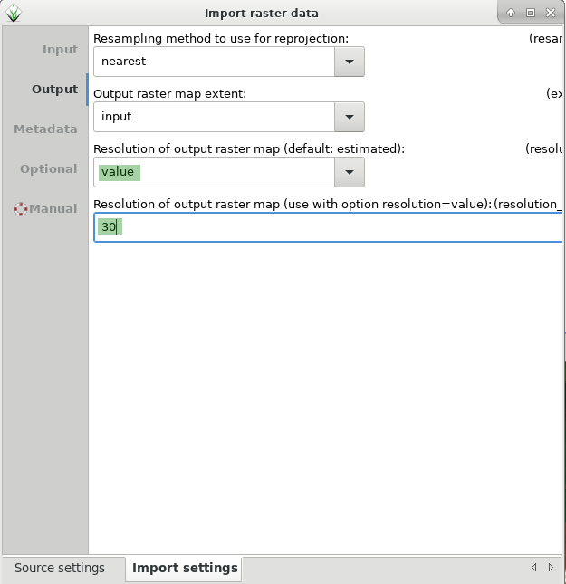

#### Importar un mapa vectorial en el proyecto NC

[figure not shown]

[figure not shown]

**Tarea**

Importar los rasters y el vector de muestra provistos dentro del mapset *curso* que crearon más arriba.

## Trabajar sin importar los mapas

En lugar de importar los datos a la base de datos de GRASS, se puede trabajar solamente **vinculando** los datos. Para ello, usamos los siguientes módulos:

- [r.external](https://grass.osgeo.org/grass-stable/manuals/r.external.html): Vincula datos raster en formatos soportados por GDAL como un pseudo raster de GRASS.
- [v.external](https://grass.osgeo.org/grass-stable/manuals/v.external.html): Crea un pseudo-vector GRASS vinculando formatos vectoriales soportados por OGR o tablas de PostGIS.

**Importante**

**No renombrar, eliminar o mover los archivos vinculados…!**

## Re-proyección de mapas

Cada location está definida por su sistema de coordenadas de referencia (*CRS* por su abreviación en Inglés), así que **re-proyectar == transferir/transformar mapas entre distintos proyectos**.

Para la **re-proyección de rasters** se definen extensión y resolución deseadas en el proyecto de destino previo a la re-proyección, mientras que para la **re-proyección de vectores** se re-proyecta todo el mapa por transformación de coordenadas.

En general, el **mecanismo** es el siguiente: se trabaja desde el proyecto de destino, y desde allí se llama a los mapas en el proyecto de origen.

**Tarea**

- Crear un nuevo proyecto (*location*) con el nombre *UTM18N* a partir de una de las bandas de L8 provistas como rasters de muestra e importarla.
- Importar a *nc_spm_08_grass7/user1* (con re-proyección al vuelo) la banda de L8 importada al proyecto *UTM18N*. ¿En qué mapset estaba?
- Definir (e imprimir) la región computacional al raster importado en ambos proyectos.

También está la opción de copiar y pegar mapas de un proyecto a otro desde el menú contextual de la GUI.

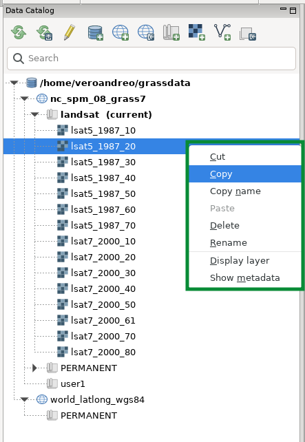

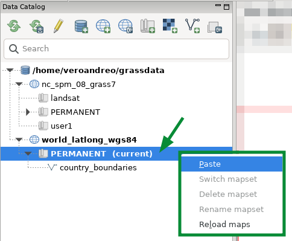

## Exportar mapas raster y vectoriales

Para exportar mapas desde GRASS GIS utilizamos los comandos [r.out.gdal](https://grass.osgeo.org/grass-stable/manuals/r.out.gdal.html) y [v.out.ogr](https://grass.osgeo.org/grass-stable/manuals/v.out.ogr.html) que nos permiten exportar a formatos soportados por GDAL/OGR.

**Tarea**

- Explorar `r.out.gdal` y `v.out.ogr` y exportar los mapas *elevation* y *roadsmajor*.
- Abrir los mapas exportados en QGIS.